# Evolutie van Muziek Door Machine Learning: Een Studie van Spotify-nummers

Thorvald Walraban van Swieten

In dit notebook ga ik de evolutie van muziek ondekken doormiddel van verschillende machine learning algoritmes en data science. Dit notebook word gebruikt als referentiepunt voor mijn onderzoeksdocument.

# EDA

Voor het toepassen van machine learning en het trekken van conclusies is het essentieel om eerst goed begrip van de data te hebben en te zorgen dat deze schoon is. Om hiervoor te zorgen wordt een Exploratory Data Analysis uitgevoerd. Deze analyse resulteert idealiter over een dataset die overzichtelijk is, waarvan patronen bekend zijn en die geschikt is voor gebruik in verdere machine learning technieken en analyses.

# Importeren van libraries

Voor de code die in dit notebook gebruikt word zijn verschillende labraries nodig, Deze worden eerst geimporteerd.

```python
import pandas as pd
from sklearn.preprocessing import StandardScaler, OneHotEncoder
from sklearn.compose import ColumnTransformer
from sklearn.pipeline import Pipeline
import seaborn as sns
import matplotlib.pyplot as plt
from sklearn.model_selection import train_test_split
from sklearn.ensemble import RandomForestClassifier
from sklearn.metrics import accuracy_score, classification_report
from sklearn.svm import SVC
from sklearn.metrics import confusion_matrix
from sklearn.linear_model import LinearRegression
import numpy as np
from sklearn.preprocessing import LabelEncoder
```

# De Dataset bekijken

Laten we een willekeurige sample van onze dataset laden.

```python
csv_filename = "all_songs.csv"
df = pd.read_csv(csv_filename)
sampled_df = df.sample(5)
display(sampled_df)
```

|  | track | artist | uri | danceability | energy | key | loudness | mode | speechiness | acousticness | instrumentalness | liveness | valence | tempo | duration_ms | time_signature | chorus_hit | sections | target | decade |
| --- | --- | --- | --- | --- | --- | --- | --- | --- | --- | --- | --- | --- | --- | --- | --- | --- | --- | --- | --- | --- |
| 9454 | For The Good Times | Ray Price | spotify:track:5J4e1T4aqU6aS8g5IjceIr | 0.275 | 0.338 | 3 | -10.199 | 1 | 0.0309 | 0.8430 | 0.000098 | 0.1960 | 0.514 | 82.377 | 227893 | 4 | 59.95875 | 9 | 1 | 1970 |
| 40585 | 6 Inch | Beyonce Featuring The Weeknd | spotify:track:0pxNyJJiL2zZZ5GgJ4JhsQ | 0.516 | 0.637 | 6 | -8.832 | 1 | 0.0632 | 0.0433 | 0.000004 | 0.1100 | 0.324 | 138.011 | 260440 | 4 | 25.23447 | 10 | 1 | 2010 |
| 5503 | Africanerías | Miguelito Valdes | spotify:track:2aRaaLuqRyIpd7890UKPfO | 0.711 | 0.599 | 0 | -6.959 | 1 | 0.0464 | 0.8080 | 0.000169 | 0.3080 | 0.803 | 116.072 | 201505 | 4 | 29.84758 | 10 | 0 | 1960 |
| 4804 | Fly Me To The Moon (In Other Words) | Tony Bennett | spotify:track:59IXYRypw3RVaWQY34DG3H | 0.277 | 0.131 | 0 | -14.900 | 0 | 0.0301 | 0.9050 | 0.001110 | 0.2380 | 0.117 | 98.654 | 251027 | 3 | 32.98207 | 11 | 1 | 1960 |
| 10811 | Lady | Little River Band | spotify:track:3fn87ydk7ihtvVr8EwjYvr | 0.457 | 0.328 | 2 | -11.928 | 1 | 0.0345 | 0.4950 | 0.000011 | 0.0615 | 0.329 | 121.187 | 297800 | 4 | 27.05917 | 15 | 1 | 1970 |

# Betekenis van kolommen

er zijn een aantal kolommen die zichzelf goed beschrijven en enkelen die onduidelijk kunnen zijn. Hieronder een uitleg van de verschillende eigenschappen.

1. Artist = artiest/bandnaam.
2. uri = spotify's link voor het nummer
3. danceability = een score van hoe "dansbaar" een nummer is gebaseerd op een calculatie die elementen als tempo, ritme, beat sterkte en herhaalbaarheid bevat
4. energy = een perceptuele maat van intensiteit en activiteit. kenmerken die bijdragen aan dit attribuut zijn onder andere dynamisch bereik, waargenomen luidheid, timbre, aanzet frequentie en algemene entropie.
5. key = De toonsoort waarin de track staat. Gehele getallen worden toegewezen aan noten volgens de standaard Pitch Class notatie. Bijvoorbeeld, 0 = C, 1 = C♯/D♭, 2 = D, enzovoort. Als er geen toonsoort is gedetecteerd, is de waarde -1. Bereik: -1 - 11
6. loudness = de gemiddelde luidheid van een track in decibellen (dB) met waardes die typisch tussen de -60 en 0 vallen. De waarde 0 wordt in muziek vaak als referentieniveau gebruikt voor wanneer de audio "clipt" ofwel vervormd.
7. mode = de modaliteit (majeur of mineur) van een track. Majeur wordt weergegeven door 1 en mineur door 0.
8. speechiness = Detecteert de aanwezigheid van gesproken woorden in een track. Hoe meer een opname exclusief op spraak lijkt hoe dichter de attribuutwaarde bij 1.0 ligt.
9. achousticness = Een meting of een track akoestisch is. 1.0 vertegenwoordigt een hoge mate van vertrouwen dat de track akoestisch is.
10. instrumentalness = Een Voorspelling of een track geen zang bevat. Geluiden zoals "ooh" en "aah" worden in deze context als instrumentaal behandeld. Hoe dichter de waarde van instrumentaliteit bij 1.0 ligt, hoe groter de kans dat de track geen vocale inhoud bevat. Waarden boven 0.5 zijn bedoeld om instrumentale tracks te vertegenwoordigen, maar de betrouwbaarheid is hoger naarmate de waarde dichter bij 1.0 komt.
11. liveness = Detecteert de aanwezigheid van een publiek in de opname. Hogere levendigheid waarden vertegenwoordigen een verhoogde kans dat de track live is opgevoerd. Een waarde boven 0.8 geeft een sterke kans aan dat de track live is.
12. Vanlence = Spotifys schatting van hoe vrolijk een nummer is. Er wordt nergens exact uitgelegd hoe ze aan deze waardes komen.
13. Tempo = Het algeheel geschatte tempo van een track in slagen per minuut (BPM)
14. Duration_ms = De duur van de track in milliseconden.
15. Time_signiture = Een geschatte maatsoort. De maatsoort (meter) is een notatie conventie om aan te geven hoeveel slagen er in elke maat (of maat) zijn. De maatsoort varieert van 3 tot 7, wat duidt op maatsoorten van "3/4" tot "7/4".
16. Chorus_hit = auteur zijn schatting van wanneer het refrein van de track zou beginnen afkomstig uit de API-oproep voor Audioanalyse. Wordt weergegeven als tijdstempel in seconde uit het begin van het derde gedeelte(section) van het nummer.
17. Sections = De hoeveelheid secties die een nummer heeft, afkomstig uit de audioanalyse van dat gegeven nummer.
18. Target = Of een nummer een Hit(1) of flop(0) is. Waarde wordt gegeven op basis van het nummer zijn aanwezigheid in de 'Billboard top 100".
19. Decade = Het decennia waaruit een gegeven nummer voor komt. Direct verstreken uit welke dataset het nummer afkomstig is.

# Missende data nagaan

Om te zorgen dat onze dataset straks geen errors veroorzaakt of valse waardes geeft is het van bellang om te checken of er missende data is.

```python
df = pd.read_csv('all_songs.csv')
null_values = df.isnull().sum()
print(null_values)
```

```
track               0
artist              0
uri                 0
danceability        0
energy              0
key                 0
loudness            0
mode                0
speechiness         0
acousticness        0
instrumentalness    0
liveness            0
valence             0
tempo               0
duration_ms         0
time_signature      0
chorus_hit          0
sections            0
target              0
decade              0
dtype: int64
```

# Schone dataset

Gelukkig zien we hier dat onze dataset geen nuldata bevat. mocht de dataset toch wel nul data bevatten of mocht er corrupte data zijn, zijn er verschillende manieren om hiermee om te gaan.

# Opties voor Missende Data

- Verwijderen: je kan in het geval van enkele rijen met missende data deze rijen verwijderen. Of in het geval van een beine lege kolommen de volledige kolom weghalen.
- Imputatie: Je kan de missende waardes vervangen door het gemiddelde, mediaan of modus van die kolom. Ook zou je hem aan kunnen laten vullen door en algoritme als k-Nearest neighbors.
- Unieke waarde: Gebruik een constante waarde zoals 0, -1, of een ander specifiek nummer dat de missende waarde aangeeft, nuttig als de nulwaarde betekenis heeft binnen de dataset.
- Hot-deck imputatie: Vervang de missende waarde door een willekeurig gekozen bestaande waarde uit dezelfde kolom.

# Opties voor corupte data

- Correctie: Identificeer en corrigeer fouten in de data handmatig of met behulp van scripts, zoals het corrigeren van typfouten of inconsistenties in de categorieën.
- Filters: Gebruik statistische tests of visualisaties om outliers te identificeren die mogelijk corrupte data vertegenwoordigen en verwijder of corrigeer deze.
- Gegevensvalidatie: Stel regels op waaraan gegevens moeten voldoen (bijv. leeftijd kan niet negatief zijn) en filter de data die deze regels overtreden.
- Gegevens Transformatie: Transformeer gegevens naar een ander formaat of bereik dat corrupte waarden minimaliseert of standaardiseert (bijv. log transformatie bij scheve verdelingen).

# aanduiding van waardes

Laten we vervolgens kijken naar de aanduiding en sprijding van onze waardes om een betere schatting te kunnen maken over of een waaarde hoog of laag is.

```python
missing_values = df.isnull().sum()
print("Ontbrekende waarden per kolom:")
print(missing_values)
print("\nStatistische samenvatting:\n", df.describe())
```

```
Ontbrekende waarden per kolom:
track               0
artist              0
uri                 0
danceability        0
energy              0
key                 0
loudness            0
mode                0
speechiness         0
acousticness        0
instrumentalness    0
liveness            0
valence             0
tempo               0
duration_ms         0
time_signature      0
chorus_hit          0
sections            0
target              0
decade              0
dtype: int64

Statistische samenvatting:
        danceability        energy           key      loudness          mode  \
count  41106.000000  41106.000000  41106.000000  41106.000000  41106.000000
mean       0.539695      0.579545      5.213594    -10.221525      0.693354
std        0.177821      0.252628      3.534977      5.311626      0.461107
min        0.000000      0.000251      0.000000    -49.253000      0.000000
25%        0.420000      0.396000      2.000000    -12.816000      0.000000
50%        0.552000      0.601000      5.000000     -9.257000      1.000000
75%        0.669000      0.787000      8.000000     -6.374250      1.000000
max        0.988000      1.000000     11.000000      3.744000      1.000000

        speechiness  acousticness  instrumentalness      liveness  \
count  41106.000000  41106.000000      41106.000000  41106.000000
mean       0.072960      0.364197          0.154416      0.201535
std        0.086112      0.338913          0.303530      0.172959
min        0.000000      0.000000          0.000000      0.013000
25%        0.033700      0.039400          0.000000      0.094000
```

[output cut: 8 more lines]

```
min        0.000000      0.000000  1.516800e+04        0.000000      0.000000
25%        0.330000     97.397000  1.729278e+05        4.000000     27.599792
50%        0.558000    117.565000  2.179070e+05        4.000000     35.850795
75%        0.768000    136.494000  2.667730e+05        4.000000     47.625615
max        0.996000    241.423000  4.170227e+06        5.000000    433.182000

           sections        target        decade
count  41106.000000  41106.000000  41106.000000
mean      10.475673      0.500000   1982.775264
std        4.871850      0.500006     17.491234
min        0.000000      0.000000   1960.000000
25%        8.000000      0.000000   1970.000000
50%       10.000000      0.500000   1980.000000
75%       12.000000      1.000000   2000.000000
max      169.000000      1.000000   2010.000000
```

# Leesbaarheid dataset

Veel van de waardes zijn in een grootte tussen de 0.0 en 1.0. om de dataset meer overzichtelijk te maken wil ik de kolommen waarbij het mogelijk is normaliseren, laten we langs de verschillende kolommen gaan die behandeld moeten worden.

# Key

heeft waardes tussen de 0 en 11. Deze waardes omzetten binnen een range van 0.0 tot 1.0 zou niet praktisch zijn omdat het eigenlijk geen numerieke data is maar catagorisch. Dit komt omdat de getallen 0 t/m 12 voor de sleutels van een volledig octaaf staan. Hierdoor zijn mediaan, stanndaard en gemiddelde waardes onlogisch omdat je geen gemiddelde sleutel kan krijgen. Om deze data toch te kunnen gebruiken in ons onderzoek word one hot encoding toegepast. Een uitleg van deze techniek word onderaan beschreven.

# Loudness

# Mode

Hoewel hierboven deze data altijd tussen de 0.0 en 1.0 te liggen, is deels numeriek en deels catagorisch. Het geeft met 1 of 0 aan of een nummer mineur of majeur is. dat is natuurlijk een catagorische stelling. maar de datapunten kunnen als boolean behandeld worden, dus numeriek. we hoeven hier dus niets aan te veranderen.

# Tempo

bevat data punten van 0 tot en met 241... dit is het tempo van het nummer in BPM (Beats Per Minute). Deze data is prima te normaliseren om overzicht te scheppen.

# Duration_ms

is exact een zelfde geval als tempo. Veel waardes met een grote spreiding die ook buiten de gewenste 0.0 t/m 1.0 vallen. De data punten geven de duur van het nummer in miliseconden aan. Dit kan net als tempo prima genormaliseerd worden.

# Time_signature

is een bijzonder geval waar de casus lijkt op mode. Hoewel de data numeriek genoteerd staat. en zelfs de volledige betekenissen numeriek zijn. valt het toch onder catagorische data. De waardes, 0 t/m 5 in ons geval (0 t/m 7 in de documentatie), staan voor maatsoorten zoals 4/4 of 3/4. Deze waardes zullen dus ook met One hot encoding omgezet worden.

# Chorus_hit

met een extreem weide spreiding van 0 t/m 433... is een tijds stempel in seconde en dus wel numeeriek. Zeker voor het doel van visualiseren is het volledig valide om deze te normaliseren.

# Section

die een weergave bied van de hoeveelheid secties of gedeeltes die een nummer bevat, kan ondanks zijn spreiding ook prima genormaliseerd worden.

# Target

valt binnen onze gewenste waardes en is een zelfde geval als mode, waar het meer als boolean beschouwd kan worden.

# Decade

geeft uiteraard het decennium aan van een gegeven nummer. hoewel de waardes nummeriek zijn, moeten we ze behandelen als catagoriale waarde. Een grote reden waarom we deze data zo willen beschouwen is omdat we een tijdsverloop onderzoek doen en deze waardes dus zo min mogelijk willen wijzigen.

# One hot encoding

Om alle categorische kolommen toch te kunnen gebruiken in onze EDA gaan we dus one hot encoding gebruiken. One hot encoding is een manier om categorische data numeriek te maken. De manier hoe dit gedaan wordt is als volgt. De kolom "key" heeft een waarde van 0 t/m 11. Deze waardes staan gelijk aan een van de 12 sleutels van een octaaf waar een nummer in geschreven kan zijn. Omdat er geen gemiddelde, mediaan of andere conclusies te maken zijn uit een kolom waar deze waardes gerepresenteerd worden als nummer, maken we voor elke waarde een kolom. Op de achtergrond in de code zien de kolommen er dan uit als Key_0, Key_1, Key_3, enzovoort. Vervolgens wordt er met een 0 of 1 (boolean) aangegeven of de waarde bij dat nummer (in die rij) van toepassing is. Deze data kunnen we voor het leesgemak in de visualisaties samenvoegen tot één eigenschap die weer "key" heet. Zo verliezen we geen leesbaarheid maar is de data uit deze kolommen en de verwerkingen ervan wel valide.

```python
columns_to_normalize = ['loudness', 'tempo', 'duration_ms', 'chorus_hit', 'sections']
columns_to_encode = ['key', 'time_signature']

numeric_transformer = Pipeline(steps=[
    ('scaler', StandardScaler())
])

categorical_transformer = Pipeline(steps=[
    ('onehot', OneHotEncoder(handle_unknown='ignore'))
])

df_normalized = pd.DataFrame(numeric_transformer.fit_transform(df[columns_to_normalize]),
                             columns=columns_to_normalize, index=df.index)

df_encoded = pd.DataFrame(categorical_transformer.fit_transform(df[columns_to_encode]).toarray(),
                          columns=categorical_transformer.named_steps['onehot'].get_feature_names_out(),
                          index=df.index)

df_combined = pd.concat([df_normalized, df_encoded,
                         df.drop(columns_to_normalize + columns_to_encode + ['track', 'artist', 'uri'], axis=1)], axis=1)

sampled_df_transformed = df_combined.sample(5)
sampled_df_transformed.style.set_table_styles(
    [{'selector': 'th', 'props': [('font-size', '12pt')]}]
)
```

|  | loudness | tempo | duration_ms | chorus_hit | sections | key_0 | key_1 | key_2 | key_3 | key_4 | key_5 | key_6 | key_7 | key_8 | key_9 | key_10 | key_11 | time_signature_0 | time_signature_1 | time_signature_3 | time_signature_4 | time_signature_5 | danceability | energy | mode | speechiness | acousticness | instrumentalness | liveness | … |
| --- | --- | --- | --- | --- | --- | --- | --- | --- | --- | --- | --- | --- | --- | --- | --- | --- | --- | --- | --- | --- | --- | --- | --- | --- | --- | --- | --- | --- | --- | --- |
| 15925 | -0.955929 | 1.727779 | -0.700239 | -0.712872 | -0.302901 | 0.000000 | 0.000000 | 0.000000 | 0.000000 | 0.000000 | 0.000000 | 1.000000 | 0.000000 | 0.000000 | 0.000000 | 0.000000 | 0.000000 | 0.000000 | 0.000000 | 0.000000 | 1.000000 | 0.000000 | 0.651000 | 0.379000 | 0 | 0.053800 | 0.520000 | 0.796000 | 0.075900 | … |
| 25463 | 1.156256 | 0.324029 | -0.692278 | -0.433104 | -0.302901 | 0.000000 | 0.000000 | 0.000000 | 0.000000 | 1.000000 | 0.000000 | 0.000000 | 0.000000 | 0.000000 | 0.000000 | 0.000000 | 0.000000 | 0.000000 | 0.000000 | 0.000000 | 1.000000 | 0.000000 | 0.384000 | 0.715000 | 0 | 0.030200 | 0.000113 | 0.763000 | 0.317000 | … |
| 13677 | -0.493165 | -0.758536 | 0.870522 | 2.615114 | 0.518152 | 0.000000 | 0.000000 | 0.000000 | 0.000000 | 0.000000 | 1.000000 | 0.000000 | 0.000000 | 0.000000 | 0.000000 | 0.000000 | 0.000000 | 0.000000 | 0.000000 | 1.000000 | 0.000000 | 0.000000 | 0.505000 | 0.469000 | 1 | 0.089600 | 0.160000 | 0.000000 | 0.086200 | … |
| 14343 | 0.664875 | -0.643100 | -0.023852 | -0.386472 | 0.723415 | 0.000000 | 0.000000 | 1.000000 | 0.000000 | 0.000000 | 0.000000 | 0.000000 | 0.000000 | 0.000000 | 0.000000 | 0.000000 | 0.000000 | 0.000000 | 0.000000 | 0.000000 | 1.000000 | 0.000000 | 0.633000 | 0.608000 | 1 | 0.090500 | 0.317000 | 0.001390 | 0.078800 | … |
| 22202 | -0.284940 | -1.231997 | 0.009998 | 1.293510 | -0.097638 | 0.000000 | 0.000000 | 1.000000 | 0.000000 | 0.000000 | 0.000000 | 0.000000 | 0.000000 | 0.000000 | 0.000000 | 0.000000 | 0.000000 | 0.000000 | 0.000000 | 0.000000 | 1.000000 | 0.000000 | 0.527000 | 0.391000 | 1 | 0.028000 | 0.004280 | 0.047700 | 0.094500 | … |

# De dataset is voorbereid, wat nu?

Hier kunnen we zien dat er een dataframe is uitgekomen die klaar is om met visualisaties en corelatie onderzoeken te analyseren. Alle numerieke data is genormaliseert om alle visualisaties zometeen goed leesbaar te maken en alle catagorische data is omgezet om gebruikt te worden in een corelatieonderzoek.

# Corelatie matrix

Laten we beginnen met een corelatie matrix waar we in een oogopslag kunnen zien Wat de corelatie is tussen verschillende Eigenschappen. Wat vooral interesant is om naar te kijken is de rij bij "Target". Daar kunnen we zien wat de relatie is tussen verschillende eigenschappen en of iets een hit of flop is.

Om de corelatie matrix goed leesbaar te maken maar wel valide voer ik een paar stappen uit.

1. Het herconstrueren van de dataframe (dit is nodig door alle gemaakte wijzigingen aan ons dataframe).
2. Het berekenen van de corelatie matrix met de nieuwe dataframe.
3. De waardes afronden om het matrix leesbaar te maken.
4. Het daadwerkelijk plotten van de matrix.

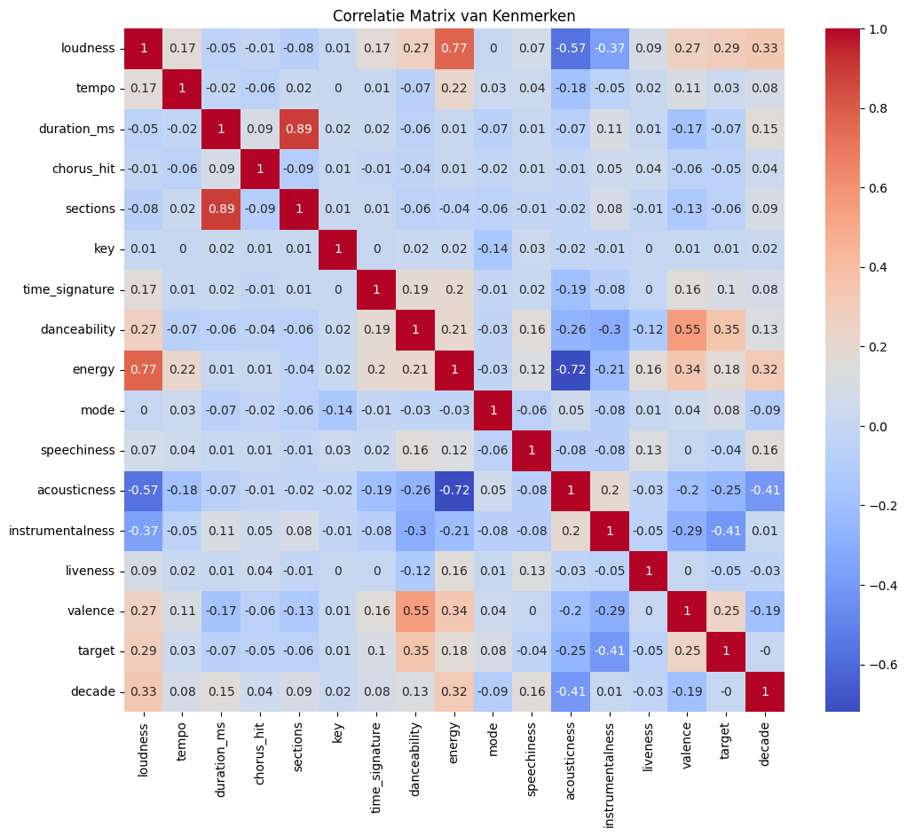

```python
#hercontrueren van het dataframe
numeric_features = df[columns_to_normalize]
categorical_features = pd.get_dummies(df[columns_to_encode])
non_transformed_features = df.drop(columns_to_normalize + columns_to_encode + ['track', 'artist', 'uri'], axis=1)
df_reconstructed = pd.concat([numeric_features, categorical_features, non_transformed_features], axis=1)

#aanmaken van de matrix
correlation_matrix_reconstructed = df_reconstructed.corr()

#leesbaar maken van de matrix
correlation_matrix_readable = correlation_matrix_reconstructed.round(2)

#plotten vand de matrix
plt.figure(figsize=(12, 10))
sns.heatmap(correlation_matrix_readable, annot=True, cmap='coolwarm', fmt='g')
plt.title('Correlatie Matrix van Kenmerken')
plt.xticks(rotation=90)
plt.yticks(rotation=0)
plt.show()
```

# Conclusies en vervolg

In de "Target" rij zijn er een aantal variabelen die veel invloed lijken te hebben op de populariteit van een nummer. Dit onderzoek gaat alleen niet over het voorspellen of een nummer populair word of niet maar hoe dit veranderd over de tijd heen. Dus een rij die ook interesant is, is decade. Enkele variabelen zijn hierdoor interesant om in de gaten te houden:

- loudness
- danceabillity
- energy
- achousticness
- instrumentalness
- valance

# Heatmap per decenium

Omdat dit onderzoek over het verschil in decenia gaat, zal ik een heatmap voor ieder decenium maken. Zo is er te zien of de corelaties per decenium verschillen of dat de corelaties gelijk blijven. Hieronder verschillende heatmaps per decenium, enkel gevult met de kolommen die potentieel interesant zijn om het overzichtelijk te maken. De andere kolommen behandelen we later nog. De code is vrijwel hetzelfde als de corelatiematrix hierboven. Wat wel afwijkt is dat dat de matrixen minder variabelen hebben maar vooral dat ik subplots heb aangemaakt om te zorgen dat niet elk matrix de groote van het scherm heeft

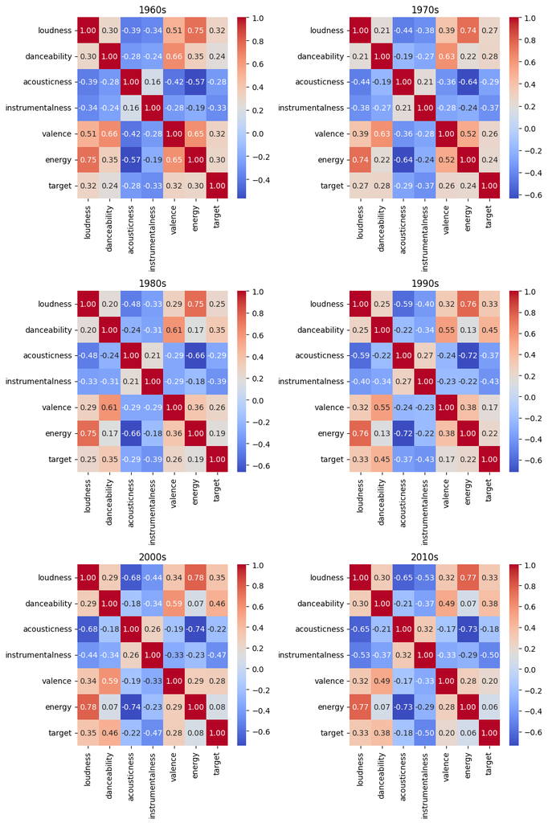

```python
import matplotlib.pyplot as plt
import seaborn as sns

# functie om de subplots aan te maken
def plot_correlation_per_decade(df_reconstructed, decades, features, target):
    n_rows = (len(decades) + 1) // 2
    fig, axes = plt.subplots(n_rows, 2, figsize=(10, 5 * n_rows))

    for i, decade in enumerate(decades):
        row, col = divmod(i, 2)
        df_decade = df[df['decade'] == decade]
        corr_matrix = df_decade[features + [target]].corr()
        sns.heatmap(corr_matrix, annot=True, fmt=".2f", cmap='coolwarm', ax=axes[row, col])
        axes[row, col].set_title(f'{decade}s')


    plt.tight_layout()
    plt.show()

# variabelen van de matrix aangeven
features = ['loudness', 'danceability', 'acousticness', 'instrumentalness', 'valence', 'energy']
target = 'target'

# matrixen scheiden per decenia
decades = df['decade'].unique()

# matrixen plotten
plot_correlation_per_decade(df, decades, features, target)
```

# Verdiepen in de waardes

# hoe deze waardes zich ontwikkelen

Het is interesant om naast de correlatie tussen de verschillende eigenschappen en de hit of flop waarde te kijken hoe de waardes van deze waarde zich ontwikkelen door de tijd heen. Laten we hiervoor lijngrafieken opstellen. In deze grafiek houden we de gemiddelde waardes van de eigenschappen uit de correlatiematrix (y as) tegenover de decenia (x as). ook Op deze manier kunnen we zien hoe de gemiddelde waardes zich ontwikkeld hebben door de jaren heen. en dit tegenover de correlatiematrixen houden. In dit geval hoeven we de genormaliseerde waardes niet te gebruiken omdat het puur gaat om het verloop van de data door de tijd heen.

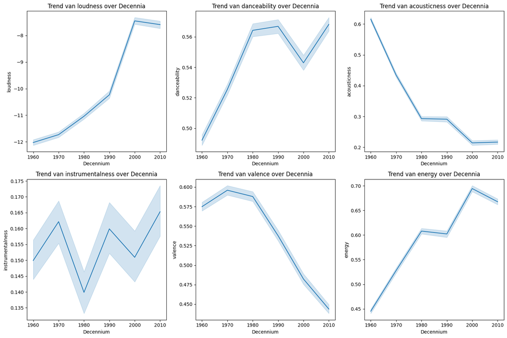

```python
# selecteren van de features
features_to_analyze = ['loudness', 'danceability', 'acousticness', 'instrumentalness', 'valence', 'energy']
df_trends = df_reconstructed[features_to_analyze + ['decade']]

# het maken van de verschillende grafieken en bepalen hoe deze eruit moeten zien
plt.figure(figsize=(15, 10))
for i, feature in enumerate(features_to_analyze, 1):
    plt.subplot(2, 3, i)
    sns.lineplot(x='decade', y=feature, data=df_trends, estimator='mean')
    plt.title(f'Trend van {feature} over Decennia')
    plt.xlabel('Decennium')
    plt.ylabel(feature)

plt.tight_layout()
plt.show()
```

# Betekenis van de grafieken

- correlatie tussen hit/flop en energy daalt door de jaren heen
- correlatie tussen hit/flop, danceabillity en instrumentalness stijgen, danceabillity daalt bij 2010
- de rest schommelt

Wat interesant is om hier te zien is dat de ontwikkeling van gemiddelde waardes niet overeen lijken te komen met de ontwikkeling in correlatie tot hit/flop. De enige lijnen die lijken overeen te komen zijn energy en danceabilllity ongeveer. energy lijkt minder uit te maken bij het bepalen of iets een hit of flop word hoe hoger de waarde is. Ook tussen 1980 -> 1990 en 2000 -> 2010 lijkt er minder verschil tussen zowel de waardes als de correlatie te zitten. Bij danceabillity zien we een constante stijging in zowel de waarde als de correlatie tot hit/flop. Wat wel buiten het patroon valt is de dip die danceabillity maakt, in waarde is dat in 2000 en in correlatie juist 2010.

# Visualiseren van het hit en flop verschil

Nu we hebben gezien wat het verband is tussen eigenschappen en de hit/flop waarde over tijd en hoe deze eigenschappen ontwikkeld zijn door de jaren heen wil ik het verschil visualiseren tussen de waardes van een eigenschap bij een hit en de waardes bij een flop. Ook wil ik weten hoe dit verschil groeit of krimpt door de decenia heen.

# Boxplot

Om dit goed te visualiseren ga ik boxplots maken waar op de y-as waardes van een eigenschap terecht komen en de x-as de decenia representeerd. Elk decenium zou een boxplot voor de flops en een boxplot voor de hits moeten bevatten. Op deze manier kunnen we per decenia per eigenschap zien wat een hit van een flop differencieert.

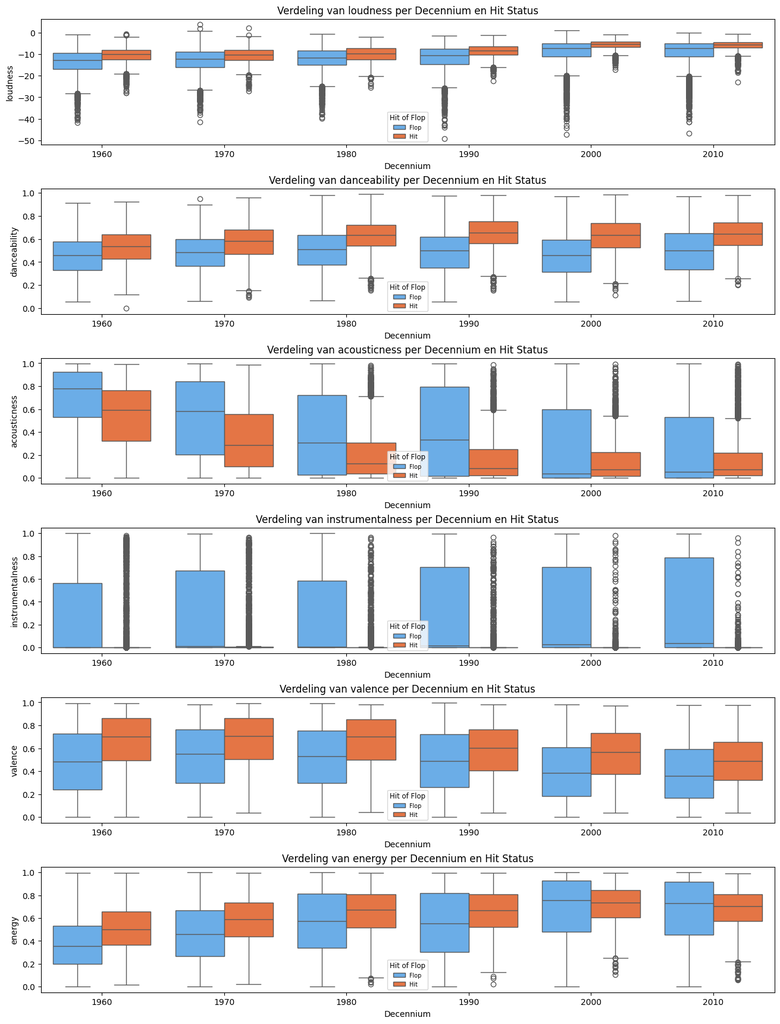

```python
# de eigenschappen waar we plots van willen
features_to_plot = ['loudness', 'danceability', 'acousticness', 'instrumentalness', 'valence', 'energy']

# wat waardes voor de subplots (zodat we meerdere grafieken onder elkaar krijgen)
num_rows = len(features_to_plot)
fig, axs = plt.subplots(num_rows, 1, figsize=(13, 2.85 * num_rows), constrained_layout=True)

# een functie die voor elk opgegeven eigenschap een plot maakt
for i, feature in enumerate(features_to_plot):
    sns.boxplot(ax=axs[i], data=df, x='decade', y=feature, hue='target',
                palette={0: '#57AEFB', 1: '#FF6B2A'})

    # wat instelbare variabelen voor de grafieken
    axs[i].set_title(f'Verdeling van {feature} per Decennium en Hit Status')
    axs[i].set_xlabel('Decennium')
    axs[i].set_ylabel(feature)

    # Legenda correct instellen voor elke subplot en de tekstgrootte aanpassen
    handles, labels = axs[i].get_legend_handles_labels()
    axs[i].legend(handles=handles, labels=['Flop', 'Hit'], title='Hit of Flop', loc='lower center', fontsize='x-small', title_fontsize= 'small')

#toont de plot
plt.show()
```

# Bevindingen uit de boxplots

# Machine learning implementatie

Nu we klaar zijn met het analyseren van onze data en een idee hebben van welke eigenschappen veel invloed hebben per decenium of iets een hot of flop is, kunnen we door met Machine Learning. In dit onderdeel gaan we doormiddel van een twee stappen machine learning proces en het gebruik van meedere modellen ontdekken hoe we de verandering van populaire muziek door de jaren heen kunnen voorspellen.

# Twee stappen methode

Tijdreeksanalyse met Classificatie combineren. Een gecombineerde aanpak waarbij tijdreeksvoorspellingen worden gebruikt als input voor de classificatiemodellen (zoals Random Forest of SVM). Dit zou het model in staat stellen rekening te houden met zowel de historische trends als de specifieke kenmerken van individuele nummers.

# 1. Tijdreeksanalyse

In dit gedeelte maken we een tijdreeksanalyse op basis van meervoudige liniere regressie. Dit doen we om de verandering in eigenschappen in de loop van tijd om te toveren naar data dat we kunnen gebruiken als input voor andere ML-algoritmes.

De reden dat ik hier niet bijvoorbeeld het ARIMA model heb gebruikt is omdat dit erg complex was voor wat ik wil aantonen en het mij niet goed lukte deze te implementeren. Ik heb toen voor liniere regressie omdat dit een simpel te begrijpen en licht algoritme is. Hierdoor snap ik nog hoe mijn data in elkaar zit en blijven mijn modellen efficient. In dit geval maak ik gebruik van meervoudige liniare regressie omdat ik veel kenmerken in een keer bereken.

# 2. clasificatiemodellen

# Deel 1: Dataset Inladen en Voorbereiden

Laten we nu onze dataset voorbereiden op onze tijdreeksanalyse.

we laden de dataset opnieuw in.

Maken de 'decade' row leesbaar voor het algoritme.

Voegen cyclische kenmerken toe voor 'decade' omdat het gaat om tijd.

definieren van features en target.

en splitten de dataset voor het trainen van het liniaire regressie model.

```python
# Laad de dataset
csv_file_path = 'all_songs.csv'
songs_df = pd.read_csv(csv_file_path)

# LabelEncoder voor 'decade'
le = LabelEncoder()
songs_df['decade_encoded'] = le.fit_transform(songs_df['decade'])

# Voeg cyclische kenmerken toe voor 'decade'
songs_df['decade_sin'] = np.sin(2 * np.pi * songs_df['decade_encoded'] / songs_df['decade_encoded'].max())
songs_df['decade_cos'] = np.cos(2 * np.pi * songs_df['decade_encoded'] / songs_df['decade_encoded'].max())

# Definieer uitgebreide features voor tijdreeksanalyse
time_series_features = ['danceability', 'energy', 'key', 'loudness', 'mode', 'speechiness',
                        'acousticness', 'instrumentalness', 'liveness', 'valence', 'tempo',
                        'duration_ms', 'time_signature', 'chorus_hit', 'sections', 'decade_sin', 'decade_cos']
X_time_series = songs_df[time_series_features]
y_time_series = songs_df['target']

# Splitst de dataset voor tijdreeksanalyse
train_size = int(0.7 * len(X_time_series))
X_train_time_series, X_test_time_series = X_time_series[:train_size], X_time_series[train_size:]
y_train_time_series, y_test_time_series = y_time_series[:train_size], y_time_series[train_size:]

# Tijdreeksmodel trainen (Meervoudige Lineaire Regressie)
time_series_model = LinearRegression()
time_series_model.fit(X_train_time_series, y_train_time_series)
y_pred_time_series = time_series_model.predict(X_time_series)

# Voeg de tijdreeksvoorspellingen toe aan de originele dataset
songs_df['time_series_predictions'] = y_pred_time_series
```

# Deel 2: Dataset Splitsen en Normaliseren

Om te zorgen dat we onze modellen kunnen testen en tunen splitsen we onze dataset op in verschillende sets.

- Een training set (om onze model op te baseren),
- een validatieset (om ons model op te tunen en beslissingen over het gebruik van het model te maken)
- en tot slot een test set (om de modellen op te testen en een conclusie te kunnen trekken over de preciesie na het tunen).

We willen uiteraard een juiste verdeling maken van onze data over deze sets. Een geode belans zou zijn training %70, validatie 15% en test 15%. Zo geven we de algoritmes genoeg data om mee te trainen maar ook genoeg om te tunen nen testen. Aangezien het trainen zo veel mogelijk data nodig heeft is deze verdeling erg logisch.

```python
from sklearn.preprocessing import StandardScaler

# Definieer features en target voor de classificatiemodellen
X = songs_df.drop(['target', 'track', 'artist', 'uri', 'decade'], axis=1)
y = songs_df['target']

# Splits de dataset in trainings-, validatie- en testsets
X_train, X_temp, y_train, y_temp = train_test_split(X, y, test_size=0.3, random_state=42)
X_val, X_test, y_val, y_test = train_test_split(X_temp, y_temp, test_size=0.5, random_state=42)

# Initialiseer en pas de StandardScaler toe
scaler = StandardScaler()
X_train_scaled = scaler.fit_transform(X_train)
X_val_scaled = scaler.transform(X_val)
X_test_scaled = scaler.transform(X_test)
numerical_columns = songs_df.select_dtypes(include=np.number).columns.drop('target')
songs_df[numerical_columns] = scaler.fit_transform(songs_df[numerical_columns])

# Voeg de tijdreeksvoorspellingen toe aan de geschaalde trainings- en validatiesets
X_train_combined = np.hstack((X_train_scaled, songs_df.loc[y_train.index, 'time_series_predictions'].values.reshape(-1, 1)))
X_val_combined = np.hstack((X_val_scaled, songs_df.loc[y_val.index, 'time_series_predictions'].values.reshape(-1, 1)))
```

# Deel 3: Trainen van Classificatiemodellen

Nu we eee analyse hebben uitgevoerd en tijdreeksvoorspellingen hebben geïntegreerd, gaan we over naar het spannende deel: het trainen van onze classificatiemodellen. In dit deel zullen we de Random Forest, Support Vector Machine (SVM), en Gradient Boosting Classifiers gebruiken om te zien hoe goed ze de hitstatus van nummers kunnen voorspellen, rekening houdend met zowel de muzikale kenmerken als de voorspelde trends in de tijd.

# Random Forest Model

Eerst trainen we het Random Forest-model. Dit is een uitstekende keuze voor ons onderzoek vanwege zijn veelzijdigheid en vermogen om grote datasets met meerdere variabelen efficiënt te verwerken. Het is een ensemble-gebaseerde methode die meerdere decission trees combineert, wat leidt tot verbeterde stabiliteit en nauwkeurigheid. Deze methode is vooral krachtig in het omgaan met overfitting.

```python
from sklearn.metrics import classification_report, accuracy_score

# Train en evalueer het Random Forest-model
rf_model = RandomForestClassifier(random_state=42)
rf_model.fit(X_train_combined, y_train)
y_pred_rf = rf_model.predict(X_val_combined)
rf_accuracy = accuracy_score(y_val, y_pred_rf)
rf_classification_report = classification_report(y_val, y_pred_rf)

print("Random Forest Accuracy:", rf_accuracy)
print("Random Forest Classification Report:")
print(rf_classification_report)
```

```
Random Forest Accuracy: 0.7984106389879987
Random Forest Classification Report:
              precision    recall  f1-score   support

           0       0.84      0.73      0.78      3064
           1       0.77      0.86      0.81      3102

    accuracy                           0.80      6166
   macro avg       0.80      0.80      0.80      6166
weighted avg       0.80      0.80      0.80      6166
```

# Support Vector Machine (SVM) Model

Het SVM-model is bijzonder effectief in het vinden van complexe relaties tussen data, dankzij zijn vermogen om niet-lineaire beslissingsgrenzen te creëren. Dit maakt het uitermate geschikt voor onze dataset, waar de relatie tussen kenmerken en de populariteit van nummers niet altijd lineair of duidelijk i zoals we zagen in de EDAs. SVM'e performance bij hog complexiteits maakt het eengoedee keuze voor onze dataset met veel kenmerken.

```python
# Train en evalueer het SVM-model
svm_model = SVC(random_state=42)
svm_model.fit(X_train_combined, y_train)
y_pred_svm = svm_model.predict(X_val_combined)
svm_accuracy = accuracy_score(y_val, y_pred_svm)
svm_classification_report = classification_report(y_val, y_pred_svm)

print("SVM Accuracy:", svm_accuracy)
print("SVM Classification Report:")
print(svm_classification_report)
```

```
SVM Accuracy: 0.8003567953292248
SVM Classification Report:
              precision    recall  f1-score   support

           0       0.87      0.70      0.78      3064
           1       0.75      0.90      0.82      3102

    accuracy                           0.80      6166
   macro avg       0.81      0.80      0.80      6166
weighted avg       0.81      0.80      0.80      6166
```

# Gradient Boosting Classifier

Gradient Boosting is een krachtige techniek die zwakkere modellen (zoals beslisbomen) combineert tot eensterkt voorspellend model. Door fouten van eerdere modellen te corrigeren, kan Gradient Boosting subtiele trends en patronen identificeren die andere modellen misschien missen. Dit past goed bij ons onderzoek, waar subtiele veranderingen in muzikale trends over tijd belangrijk kunnen zijn voor de nauwkeurigheid van de voorspelling.

```python
from sklearn.ensemble import GradientBoostingClassifier

# Train het Gradient Boosting-model
gb_model = GradientBoostingClassifier(random_state=42)
gb_model.fit(X_train_combined, y_train)
y_pred_gb = gb_model.predict(X_val_combined)

# Evalueer de nauwkeurigheid en het classification report van het Gradient Boosting-model
gb_accuracy = accuracy_score(y_val, y_pred_gb)
gb_classification_report = classification_report(y_val, y_pred_gb)

print("Gradient Boosting Accuracy:", gb_accuracy)
print("Gradient Boosting Classification Report:")
print(gb_classification_report)
```

```
Gradient Boosting Accuracy: 0.7886798572818683
Gradient Boosting Classification Report:
              precision    recall  f1-score   support

           0       0.84      0.71      0.77      3064
           1       0.75      0.87      0.81      3102

    accuracy                           0.79      6166
   macro avg       0.80      0.79      0.79      6166
weighted avg       0.80      0.79      0.79      6166
```

# Conclusie van de prestaties

Deze resultaten benadrukken een belangrijke afweging in classificatiemodellen: het balanceren tussen het correct identificeren van positieve gevallen (hits) en het voorkomen van vals-positieven. De hogere recall voor hits suggereert dat onze modellen goed zijn in het herkennen van potentiële hits, maar dit kan ten koste gaan van precisie, wat leidt tot meer vals-positieven. Dit is een cruciaal inzicht voor ons onderzoek, omdat het aantoont dat terwijl we goed zijn in het vinden van wat mogelijk populair zal zijn, we ook het risico lopen om nummers ten onrechte als hits te classificeren.

In onze volgende stap, hyperparameter tuning, zullen we proberen deze balans te verbeteren. We zullen zoeken naar de optimale instellingen die niet alleen de nauwkeurigheid verhogen, maar ook zorgen voor een evenwichtige verhouding tussen precisie en recall. Dit zal ons helpen een meer genuanceerd en accuraat voorspellingsmodel te bouwen voor de evolutie van populaire muziek door de jaren heen.

# Hyperparameter Tuning

nHyperparameter tuning is een essentieel proces in machine learning om de prestaties van modellen te optimaliseren. In ons onderzoek kiezen we voor Grid Search, een populaire en grondige methode die alle mogelijke combinaties van de opgegeven hyperparameters doorzoekt. Deze methode is ideaal omdat het ons in staat stelt de invloed van elke parametercombinatie op de modelprestaties systematisch te beoordelen.n

# Hyperparameter Tuning voor Random Forest

- n_estimators: Het aantal bomen in het bos. Meer bomen kunnen de nauwkeurigheid verbeteren, maar vergroten ook de rekenkosten.
- max_features: Het aantal kenmerken dat wordt overwogen voor het splitsen bij elke knoop. Verschillende waarden kunnen de diversiteit van de bomen in het bos beïnvloeden.
- max_depth: De maximale diepte van elke boom. Diepere bomen kunnen complexere patronen vastleggen, maar verhogen het risico op overfitting.epth.

```python
from sklearn.model_selection import GridSearchCV
from sklearn.ensemble import RandomForestClassifier

# Parameters voor Grid Search
rf_param_grid = {
    'n_estimators': [100, 200, 300],
    'max_features': ['sqrt'],
    'max_depth': [10, 20, 30, None]
}

# Grid Search initialiseren voor Random Forest
rf_grid_search = GridSearchCV(estimator=RandomForestClassifier(random_state=42),
                              param_grid=rf_param_grid,
                              cv=3,
                              n_jobs=-1,
                              verbose=2)

# Voer Grid Search uit
rf_grid_search.fit(X_train_combined, y_train)


# Beste parameters en beste score
print("Beste Parameters voor Random Forest:", rf_grid_search.best_params_)
print("Beste Score voor Random Forest:", rf_grid_search.best_score_)
```

```
Fitting 3 folds for each of 12 candidates, totalling 36 fits
Beste Parameters voor Random Forest: {'max_depth': 30, 'max_features': 'sqrt', 'n_estimators': 300}
Beste Score voor Random Forest: 0.8032596948875971
```

# Hyperparameter Tuning voor SVM

Vervolgens gaan we het SVM-model tunen. We zullen vooral kijken naar de parameters C en gamma.

- C: Regularisatieparameter. Een lagere waarde verhoogt de regularisatiekracht, wat kan helpen om overfitting te verminderen.
- gamma: Bepaalt de invloed van een enkele trainingsvoorbeeld. Lage waarden geven een verreikende invloed, terwijl hoge waarden leiden tot modellen die meer afhankelijk zijn van de trainingsdata.

```python
from sklearn.svm import SVC

# Parameters voor Grid Search
svm_param_grid = {
    'C': [0.1, 1, 10],
    'gamma': ['scale', 'auto'],
    'kernel': ['rbf', 'linear']
}

# Grid Search initialiseren voor SVM
svm_grid_search = GridSearchCV(estimator=SVC(random_state=42),
                               param_grid=svm_param_grid,
                               cv=3,
                               n_jobs=-1,
                               verbose=2)

# Voer Grid Search uit
svm_grid_search.fit(X_train_combined, y_train)

# Beste parameters en beste score
print("Beste Parameters voor SVM:", svm_grid_search.best_params_)
print("Beste Score voor SVM:", svm_grid_search.best_score_)
```

```
Fitting 3 folds for each of 12 candidates, totalling 36 fits
Beste Parameters voor SVM: {'C': 10, 'gamma': 'auto', 'kernel': 'rbf'}
Beste Score voor SVM: 0.7993672944300396
```

# Hyperparameter Tuning voor Gradient Boosting

Ten slotte voeren we hyperparameter tuning uit voor het Gradient Boosting-model. We zullen parameters zoals learning_rate, n_estimators, en max_depth aanpassen

- learning_rate: Bepaalt hoe snel het model leert. Een lagere waarde vereist een hoger aantal n_estimators, maar kan leiden tot een meer robuust model.
- n_estimators: Het aantal opeenvolgende bomen die worden gebouwd. Meer bomen kunnen de prestaties verbeteren tot een bepaald punt.
- max_depth: Net als bij Random Forest, controleert deze parameter de diepte van elke boom.hon

```python
from sklearn.ensemble import GradientBoostingClassifier

# Parameters voor Grid Search
gb_param_grid = {
    'learning_rate': [0.01, 0.1, 0.2],
    'n_estimators': [100, 200, 300],
    'max_depth': [3, 4, 5]
}

# Grid Search initialiseren voor Gradient Boosting
gb_grid_search = GridSearchCV(estimator=GradientBoostingClassifier(random_state=42),
                              param_grid=gb_param_grid,
                              cv=3,
                              n_jobs=-1,
                              verbose=2)

# Voer Grid Search uit
gb_grid_search.fit(X_train_combined, y_train)

# Beste parameters en beste score
print("Beste Parameters voor Gradient Boosting:", gb_grid_search.best_params_)
print("Beste Score voor Gradient Boosting:", gb_grid_search.best_score_)
```

```
Fitting 3 folds for each of 27 candidates, totalling 81 fits
Beste Parameters voor Gradient Boosting: {'learning_rate': 0.1, 'max_depth': 5, 'n_estimators': 300}
Beste Score voor Gradient Boosting: 0.8081600535287765
```

# Reflectie op Hyperparameter Tuning

# Reflectie op de Resultaten

Hoewel ze vergelijkbare resultaten hebben blijkt Gradient boosting in mijn onderzoek toch iets sterker dan random forrest en lijkt het, het beste model te zijn voor mijn onderzoek.

Deze resultaten benadrukken de diepte van de muzikale trends die we onderzoeken. Ze suggereren dat zowel de breedte van de analyse (zoals aangegeven door max_features in Random Forest) als de diepte van de leerprocessen (zoals weerspiegeld in max_depth voor Gradient Boosting en Random Forest) cruciaal zijn voor het begrijpen van de evolutie van muziek.

# Betrouwbaarheid en Vervolgonderzoek

De verbeterde modelprestaties geven mij vertrouwen in de betrouwbaarheid van deze analyse. Echter, zoals met elk onderzoek, zijn er altijd mogelijkheden voor verdieping en uitbreiding. Enkele suggesties voor toekomstig onderzoek zijn:

- Feature Engineering: Verder onderzoek naar het creëren en selecteren van kenmerken kan leiden tot meer inzichtelijke modellen. Bijvoorbeeld, het onderzoeken van interacties tussen kenmerken of het ontwikkelen van nieuwe kenmerken die cruciale muzikale aspecten vastleggen.
- Alternatieve Modellen: Het verkennen van andere geavanceerde machine learning en deep learning modellen kan nieuwe perspectieven bieden. Modellen zoals convolutionele neurale netwerken (CNN's) of recurrente neurale netwerken (RNN's) kunnen bijzonder geschikt zijn voor tijdreeksanalyse in muziek.
- Meer Gegevens: Het toevoegen van meer gegevens, zowel in termen van het aantal nummers als extra kenmerken zoals songteksten of meer gedetailleerde muzikale analyse, zou de modellen kunnen versterken.
- Dynamische Tijdreeksmodellen: Het verkennen van dynamische tijdreeksmodellen zoals ARIMA of LSTM voor meer geavanceerde voorspellingen van muzikale trends kan leiden tot nog nauwkeurigere inzichten.

De resultaten van dit onderzoek bieden een solide basis voor verder onderzoek en ontwikkeling in de studie van muziekevolutie. De verbeteringen door hyperparameter tuning bevestigen dat onze data-preparatie adequaat was, maar er is altijd ruimte voor verfijning. Het opnieuw beoordelen van de data-preparatie in het licht van nieuwe inzichten kan leiden tot nog accuratere modellen en diepere inzichten in de dynamische wereld van muziek.